# task4

Manvydas Sokolovas

2016 m kovas 15 d

Aplanke `task4` yra duomenų failas, kuriame rasite nekilnojamo turto (o tiksliau gyvenamųjų būtų) kainas ir kaikurias jų charakteristikas. Jūsų užduotis atlikti išsamią tiesinę regresiją. Lygtis reikalinga prekybos agentams, kad geriau suprastų kokią įtaką skirtingos charakteristikos daro galutinei kainai.

Nuskaitomi duomenys:

```r
setwd("C:/Users/manvi_000/Desktop/MIF/Econometrics/task4")
duom1 <- read.csv2("data.csv")
```

Sudaromas modelis:

```r
mod1 <- lm(kaina~plotas+aukstas+garsoIzoliacija+silumosLaidumas+atstumasIkiPrekybosCentro,data=duom1)
```

Ieškoma išsskirčių naudojant outlierTest, kuris yra “car” pakete:

```r
library("car")
outlierTest(mod1)
```

```
##      rstudent unadjusted p-value Bonferonni p
## 253 14.334591         2.5467e-34   6.4687e-32
## 254 -7.221533         6.3423e-12   1.6110e-09
```

```r
# Testas parodo išskirtis. Šiuo atveju tai 253 ir 254 eilutese esantys duomenys
```

Modelio grafinis atvaizdavimas:

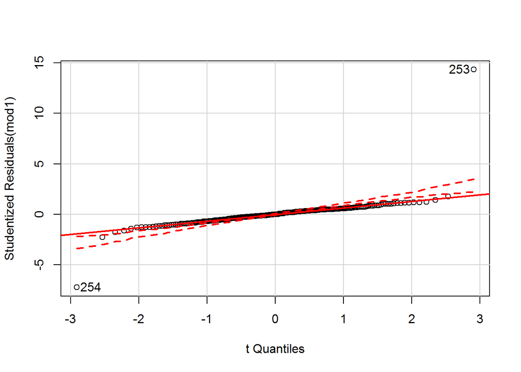

```
## 254 253
##   1 254
```

```r
qqPlot(mod1, id.n=2)
```

```r
# Galima pastebėti, jog išskirtys yra 253 ir 254 eilutėse.
```

Ištrinamos išskirtis:

```r
duom2 <- duom1[-c(253,254),]
```

Instaliuojamas “usdm” paketas, kad veiktų VIF funkcija. Modelis tikrinamas su VIF testu. Jei kurio nors kintamojo VIF koeficientas > 10, tai yra multikolinearumo problema:

```r
library("usdm")
vif(duom2)
```

```
##                   Variables       VIF
## 1                     kaina 12.357397
## 2                    plotas 11.331039
## 3                   aukstas  1.141261
## 4           garsoIzoliacija 11.629961
## 5           silumosLaidumas 11.194482
## 6 atstumasIkiPrekybosCentro  1.011357
```

```r
# VIF koeficientai prie garso izoliacijos ir šilumos laidumo yra didesni nei 10. Tai reiškia, jog turime multikolinearumo problemų.
```

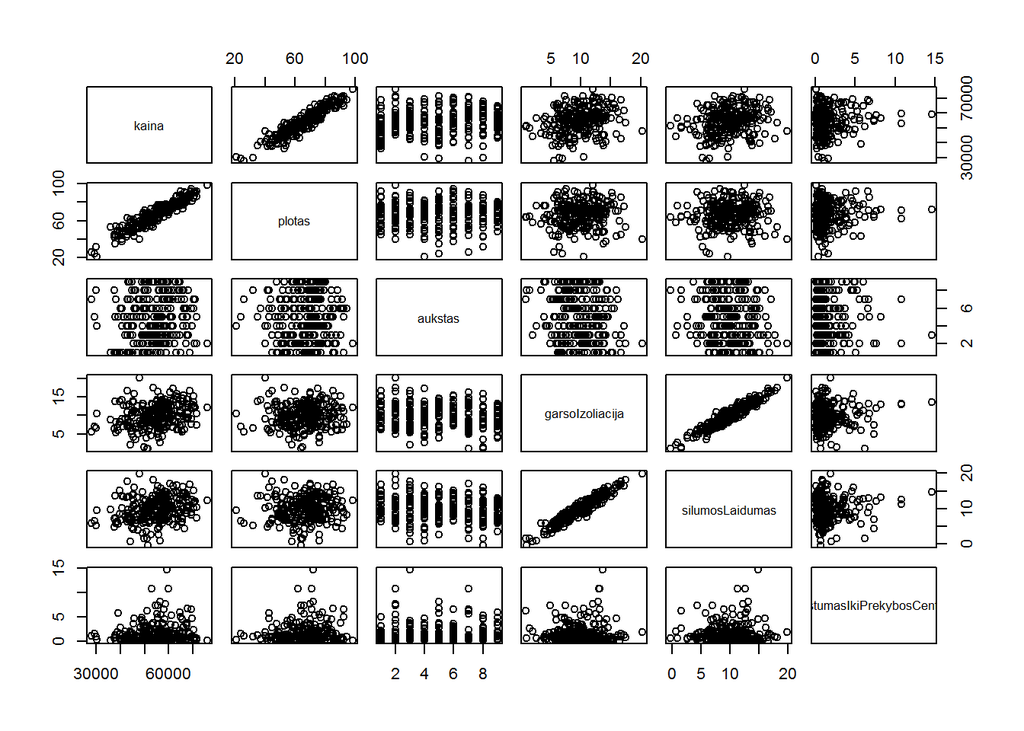

```r
plot(duom2)
```

```r
# Pagal grafiką galima matyti, jog garso izoliacija ir šilumos laidumas koreliuoja.
```

```r
cor(duom2$garsoIzoliacija,duom2$silumosLaidumas)
```

```
## [1] 0.9541582
```

```r
# Atlikus koreliacijos testą. Hipotezė, jog šie kintamieji stipriai koreliuoja pasitvirtina.
```

Atmetus garso izoliaciją sudaromas naujas modelis:

```r
mod2 <- lm(kaina~plotas+aukstas+silumosLaidumas+atstumasIkiPrekybosCentro,data=duom2)
summary(mod2)
```

```
##
## Call:
## lm(formula = kaina ~ plotas + aukstas + silumosLaidumas + atstumasIkiPrekybosCentro,
##     data = duom2)
##
## Residuals:
##    Min     1Q Median     3Q    Max
##  -9212  -1540     92   1789   5862
##
## Coefficients:
##                           Estimate Std. Error t value Pr(>|t|)
## (Intercept)                7966.67     977.86   8.147 1.86e-14 ***
## plotas                      599.37      12.13  49.410  < 2e-16 ***
## aukstas                     318.66      63.49   5.019 9.95e-07 ***
## silumosLaidumas             527.45      47.52  11.099  < 2e-16 ***
## atstumasIkiPrekybosCentro    85.45      81.38   1.050    0.295
## ---
## Signif. codes:  0 '***' 0.001 '**' 0.01 '*' 0.05 '.' 0.1 ' ' 1
##
## Residual standard error: 2547 on 247 degrees of freedom
## Multiple R-squared:  0.9162, Adjusted R-squared:  0.9149
## F-statistic: 675.5 on 4 and 247 DF,  p-value: < 2.2e-16
```

```r
# Kintamojo pavadinimu "atstumasIkiPrekybosCentro" t value = 1.050 < |2|.
```

Atmetus šilumos laidumą sudaromas naujas modelis:

```r
mod3 <- lm(kaina~plotas+aukstas+garsoIzoliacija+atstumasIkiPrekybosCentro,data=duom2)
summary(mod3)
```

```
##
## Call:
## lm(formula = kaina ~ plotas + aukstas + garsoIzoliacija + atstumasIkiPrekybosCentro,
##     data = duom2)
##
## Residuals:
##     Min      1Q  Median      3Q     Max
## -8560.8 -1425.3    93.5  1840.6  5950.4
##
## Coefficients:
##                           Estimate Std. Error t value Pr(>|t|)
## (Intercept)                7408.08     978.24   7.573 7.28e-13 ***
## plotas                      598.49      11.94  50.143  < 2e-16 ***
## aukstas                     334.36      62.60   5.341 2.10e-07 ***
## garsoIzoliacija             579.74      49.79  11.644  < 2e-16 ***
## atstumasIkiPrekybosCentro    83.78      80.05   1.047    0.296
## ---
## Signif. codes:  0 '***' 0.001 '**' 0.01 '*' 0.05 '.' 0.1 ' ' 1
##
## Residual standard error: 2506 on 247 degrees of freedom
## Multiple R-squared:  0.919,  Adjusted R-squared:  0.9176
## F-statistic: 700.2 on 4 and 247 DF,  p-value: < 2.2e-16
```

```r
# Kintamojo pavadinimu "atstumasIkiPrekybosCentro" t value = 1.047 < |2|.
```

Abiejuose modeliuose kintamojo “atstumasIkiPrekybosCentro” t value < |2|. Tai galima teigti, jog atstumas iki prekybos centro yra statistiškai nereiksmingas kainai:

```r
mod4 <- lm(kaina~plotas+aukstas+silumosLaidumas, data=duom2)
mod5 <- lm(kaina~plotas+aukstas+garsoIzoliacija, data=duom2)
```

Lieka išsiaškinti, kuris modelis geresnis. Tam naudojamas Akaike kriterijus - kuo mažesnis, tuo geriau:

```r
AIC(mod4)
```

```
## [1] 4673.994
```

```r
AIC(mod5)
```

```
## [1] 4665.689
```

```r
# Pagal ši kriterijų mod5 gerenis nei mod4.
```

Ištirti ar duomenys nėra heteroskedastiški naudojamas ncvTest:

```r
ncvTest(mod5)
```

```
## Non-constant Variance Score Test
## Variance formula: ~ fitted.values
## Chisquare = 2.008359    Df = 1     p = 0.1564345
```

```r
# Kadangi p-value > 0.05, tai H0 hipotezė priimama - duomenys homoskedastiški.
```

Tikrinama autokoreliacija:

```r
durbinWatsonTest(mod5)
```

```
##  lag Autocorrelation D-W Statistic p-value
##    1      0.05655875      1.882357   0.324
##  Alternative hypothesis: rho != 0
```

```r
# p-value > 0.05 - liekanos nėra autokoreliuotos.
```

Pagal galutinį modelį kaina priklauso nuo ploto, auksto ir garso izoliacijos. Galutinis modelis yra: kaina = 7474.4 + 599.4plotas + 334aukstas + 581.2garsoIzoliacija + e$. Koeficientai parodo kiek pakis kaina pakitus vienam iš kintamujų vienu vienetu, o kitiems išlikus pastoviais.